# Annual Report

Sam Graf

2026-01-27

## Tagging Summary

### All Data Excludes TGM

Throughout the study, there have been a total of 18821 fish tagged with PIT tags. Of these fish, 6915 were trout or sculpin tagged within the study area. 11900 fish were Tiger Muskies tagged and released in Shadow Mountain Reservoir, and 6 tags were mergansers tagged as part of an avian predation study. There have been 762 instances of fish recapture throughout the study period. The table below breaks down release and recapture data by year and species on tags other than Tiger Muskies.

| Event | Year | Species | n |
| --- | --- | --- | --- |
| Recapture | 2021 | LOC | 109 |
| Recapture | 2021 | MTS | 12 |
| Recapture | 2021 | RBT | 14 |
| Recapture | 2022 | LOC | 111 |
| Recapture | 2022 | MTS | 11 |
| Recapture | 2022 | RBT | 12 |
| Recapture | 2023 | LOC | 105 |
| Recapture | 2023 | MTS | 12 |
| Recapture | 2023 | RBT | 14 |
| Recapture | 2024 | LOC | 91 |

[output cut: 44 more lines]

The following interactive plot shows the length distribution of tagged fish (besides Tiger Muskies) by year, length and species. The proceeding table shows summary statistics of released species’ lengths and weights by year.

[interactive chart not shown]

| Year | Species | Minimum Length (mm) | Maximum Length (mm) | Average Length (mm) | SD Length (mm) | Minimum Weight (g) | Maximum Weight (g) | Average Weight (g) | SD Weight (g) |
| --- | --- | --- | --- | --- | --- | --- | --- | --- | --- |
| 2020 | LOC | 77 | 630 | 265.83 | 91.35 | 2 | 2714 | 252.96 | 247.06 |
| 2020 | MTS | 71 | 142 | 104.81 | 17.83 | 2 | 47 | 18.42 | 9.52 |
| 2020 | RBT | 68 | 656 | 222.24 | 118.12 | 3 | 3383 | 221.27 | 364.39 |
| 2020 | RXN | 409 | 409 | 409 |  | 620 | 620 | 620 |  |
| 2021 | LOC | 128 | 530 | 300.02 | 72.28 | 14 | 1282 | 306.91 | 184.55 |
| 2021 | MTS | 63 | 138 | 105.85 | 19.52 | 4 | 43 | 17.81 | 10.04 |
| 2021 | RBT | 126 | 591 | 316.67 | 85.43 | 15 | 1925 | 373.48 | 280.17 |
| 2021 | RXN | 355 | 512 | 409.75 | 69.76 | 431 | 1374 | 747.5 | 424.69 |
| 2022 | LOC | 132 | 575 | 288.68 | 79.76 | 27 | 1894 | 277.86 | 209.66 |
| 2022 | MTS | 78 | 127 | 98.53 | 11.86 | 7 | 31 | 13.52 | 5.1 |

[output cut: 14 more lines]

There have been a total of 27 sites where tagged fish have been released and 24 sites where fish have been recaptured over the course of the study. The following tables show yearly counts of released and recaptured fish by site and species.

| Year | ReleaseSite | Species | Event | n |
| --- | --- | --- | --- | --- |
| 2020 | Below Confluence Antenna | MTS | Release | 37 |
| 2020 | Below Red Barn Diversion #1 | LOC | Release | 88 |
| 2020 | Below Red Barn Diversion #1 | RBT | Release | 24 |
| 2020 | Fraser River Ranch | LOC | Release | 107 |
| 2020 | Fraser River Ranch | MTS | Release | 23 |
| 2020 | Fraser River Ranch | RBT | Release | 51 |
| 2020 | Fraser River Ranch |  | Release | 1 |
| 2020 | Hitching Post | LOC | Release | 62 |
| 2020 | Hitching Post | RBT | Release | 32 |
| 2020 | Kaibab Park | LOC | Release | 180 |

[output cut: 237 more lines]

| Year | RecaptureSite | Species | n |
| --- | --- | --- | --- |
| 2021 | Below Red Barn Diversion #2 | LOC | 5 |
| 2021 | Chimney Rock Above Island | LOC | 3 |
| 2021 | Chimney Rock Below Island | LOC | 2 |
| 2021 | Chimney Rock Below Island | RBT | 1 |
| 2021 | Dark Timber Above Railroad | LOC | 9 |
| 2021 | Dark Timber Above Railroad | RBT | 2 |
| 2021 | Fraser River Ranch | LOC | 11 |
| 2021 | Fraser River Ranch | RBT | 3 |
| 2021 | Hitching Post | LOC | 6 |
| 2021 | Hitching Post | RBT | 4 |

[output cut: 108 more lines]

## Movement Summary

Fish detected by antennas, released, or recaptured are assigned a one letter “State”, defined as a specific section of the river outlined in the map below. The following tables summarize activity in the Connectivity Channel (CRCC) as defined by movement between the “States” upstream of the channel, downstream of the channel, and within the channel throughout a fish’s encounter history. Antenna locations can be toggled with the layer control.

[interactive chart not shown]

| Total Fish Detected In Channel (Including Release) | Total Fish Swam Downstream Through Channel | Total Fish Swam Upstream Through Channel |
| --- | --- | --- |
| 639 | 98 | 135 |

| Species | Total Fish Detected In Channel | Total Fish Swam Downstream Through Channel | Total Fish Swam Upstream Through Channel |
| --- | --- | --- | --- |
| LOC | 481 | 76 | 103 |
| MERG | 3 | 1 | 0 |
| MTS | 2 | 0 | 0 |
| No Info | 1 | 0 | 0 |
| RBT | 152 | 21 | 32 |

| Length Bin | Total Fish Detected In Channel | Total Fish Swam Downstream Through Channel | Total Fish Swam Upstream Through Channel |
| --- | --- | --- | --- |
| 0-100 | 4 | 1 | 0 |
| 100-200 | 90 | 10 | 8 |
| 200-300 | 242 | 27 | 41 |
| 300-400 | 247 | 43 | 71 |
| 400-500 | 51 | 16 | 13 |
| 500+ | 5 | 1 | 2 |

Upstream or downstream movements of fish occur when a fish is detected or recaptured in a different area than before, even if a fish remained in the same state. By monitoring these movements over time, we can start to see patterns about when fish activity is highest. “No Movement” is defined when a fish hits the same antenna as before on a different day. The following graph and table show an overall increase in activity in the Spring and Fall, when spawning occurs in rainbow trout and brown trout and water temperatures change.

[interactive chart not shown]

| Month | Day | movement_only | total_events |
| --- | --- | --- | --- |
| 1 | 1 | No Movement | 22 |
| 1 | 2 | No Movement | 25 |
| 1 | 3 | No Movement | 24 |
| 1 | 3 | Upstream Movement | 2 |
| 1 | 4 | Downstream Movement | 1 |
| 1 | 4 | No Movement | 23 |
| 1 | 5 | Downstream Movement | 2 |
| 1 | 5 | No Movement | 26 |
| 1 | 6 | No Movement | 23 |
| 1 | 6 | Upstream Movement | 1 |

[output cut: 934 more lines]

The following graph and table shows total movements by fish size.

[interactive chart not shown]

| Length Bin (mm) | Downstream Movement | Initial Release | No Movement | Upstream Movement | Changed Rivers | NA | DS Percentage |
| --- | --- | --- | --- | --- | --- | --- | --- |
| 0-100 | 78 | 565 | 318 | 87 |  |  | 0.4727272727272727 |
| 100-200 | 506 | 1572 | 2354 | 417 | 2 |  | 0.5482123510292525 |
| 200-300 | 1217 | 2050 | 7071 | 852 | 3 |  | 0.5882068632189463 |
| 300-400 | 1492 | 2296 | 9104 | 1261 |  | 1 | 0.5419542317471849 |
| 400-500 | 346 | 405 | 1485 | 213 |  |  | 0.6189624329159212 |
| 500+ | 27 | 33 | 100 | 14 |  |  | 0.6585365853658537 |

## Antenna data

When a tagged fish swims across an antenna, it registers a detection on that antenna. When the fish remains on an antenna, it registers detections until the fish swims out of the detection field. Combined with realease and recapture data, there are 5159356 rows of detection data to manage including marker tags and unknown tags. Of those, 3470993 are from known released fish. The following graph and table show the raw amount of detections per antenna across the entirety of the study.

[interactive chart not shown]

| AntennaSite | Event | Year | Raw Detections (Released Fish Only) |
| --- | --- | --- | --- |
| Connectivity Channel Downstream (Downstream) | CD1 | 2026 | 25 |
| Connectivity Channel Downstream (Upstream) | CD2 | 2026 | 9 |
| Confluence (Downstream) | CF5 | 2026 | 1230 |
| Confluence (Upstream) | CF6 | 2026 | 1094 |
| Connectivity Channel Upstream (Downstream) | CU1 | 2026 | 30 |
| Connectivity Channel Upstream (Upstream) | CU2 | 2026 | 10 |
| Hitching Post (Upstream) | HP4 | 2026 | 70 |
| Red Barn (Downstream) | RB1 | 2026 | 93 |
| Red Barn (Upstream) | RB2 | 2026 | 153 |
| Connectivity Channel Downstream (Downstream) | CD1 | 2025 | 21124 |

[output cut: 62 more lines]

| Event Type | Raw Detections (Released Fish Only) |
| --- | --- |
| Biomark | 1305065 |
| Mobile | 7641 |
| Recapture | 762 |
| Recapture and Release | 219 |
| Release | 18602 |
| Stationary | 2138704 |

| Event Type | Year | Raw Detections (Released Fish Only) |
| --- | --- | --- |
| Stationary | 2026 | 2714 |
| Biomark | 2025 | 45531 |
| Mobile | 2025 | 2184 |
| Recapture | 2025 | 245 |
| Recapture and Release | 2025 | 28 |
| Release | 2025 | 7821 |
| Stationary | 2025 | 262759 |
| Biomark | 2024 | 383737 |
| Mobile | 2024 | 710 |
| Recapture | 2024 | 117 |

[output cut: 23 more lines]

Sometimes these antennas lose power for a certain period of time. Stationary Antennas were down for 3.42% of the total time across all Stationary Antennas. All individual Stationary antennas were down for a total of 572.83 days out of a total of 16733.01 days of total time across all Stationary antennas. Biomark antennas were down for 2.06% of the total time across all Biomark antennas. All individual Biomark antennas were down for a total of 31.35 days out of a total of 1525.72 days of total time across all Biomark Antennas.

## Unique Detections

Of a possible 6921 tagged fish (excluding Tiger Muskies), 3895 have been detected or recaptured.

Stationary antennas detected 1256 fish that were not detected by mobile, biomark, or recapture methods. Biomark antennas detected 146 fish that were not detected by mobile, stationary, or recapture methods. Mobile antennas detected 1144 fish that were not detected by biomark, stationary, or recapture methods. There were 185 fish recaptured that were not detected by biomark, stationary, or mobile methods.

| Method | Total Overall Detections (Released Fish Only) | Released Tags Detected | % Tags Detected | Unique Tags |
| --- | --- | --- | --- | --- |
| Biomark | 1305065 | 377 | 0.05447189712469296 | 146 |
| Mobile | 7641 | 2060 | 0.2976448490102586 | 1144 |
| Recapture | 762 | 628 | 0.09073833261089438 | 185 |
| Stationary | 2138704 | 2200 | 0.3178731397196937 | 1256 |

## Avian Predation

Throughout the duration of the study, we have identified 89 fish that have been predated by birds. These tags are found a few different ways:

- By identifying missing antennas in their encounter history, ie hitting an antenna different than the ones we’d expect them to hit
- Identifying instances where a tag moved quickly, or disproportionately far throughout its encounter history or even just one move
- Tagging actual birds known to predate fish (in this case, Mergansers) and comparing their encounter histories to suspected predated tags.

Below is the encounter history of a Merganser tagged in 2024. Activity is excessive between Red Barn and Hitching Post and later do not follow a typical fish sequence when travelling upstream. The Merganser was detected on the Hitching Post antenna below the dam, then was detected on an antenna above the dam without hitting other antennas between, as shown in the animation below. The Merganser also is typically detected briefly on an antenna before travelling off of it. By recognizing movements patterns of known birds, we can apply this pattern to finding tags predated by birds.

| TAG | Datetime | Species | Event | Previous Event | Time Since Previous Detection (For Sorting) | Time Since Previous Detection (User Friendly) |
| --- | --- | --- | --- | --- | --- | --- |
| 230000087407 | 2024-08-08T12:30:00Z | MERG | Release |  |  | First Detection in History |
| 230000087407 | 2024-08-20T15:36:49Z | MERG | RB1 | Release | -1048009 | 12.13 days |
| 230000087407 | 2024-08-20T15:36:57Z | MERG | RB2 | RB1 | -8 | 8 seconds |
| 230000087407 | 2024-08-20T20:14:37Z | MERG | RB2 | RB2 | -16660 | 4.63 hours |
| 230000087407 | 2024-08-22T07:34:52Z | MERG | RB1 | RB2 | -127215 | 1.47 days |
| 230000087407 | 2024-08-22T07:35:03Z | MERG | RB1 | RB1 | -11 | 11 seconds |
| 230000087407 | 2024-08-22T07:35:23Z | MERG | RB2 | RB1 | -20 | 20 seconds |
| 230000087407 | 2024-08-22T16:45:05Z | MERG | HP3 | RB2 | -32982 | 9.16 hours |
| 230000087407 | 2024-08-22T16:45:14Z | MERG | HP3 | HP3 | -9 | 9 seconds |
| 230000087407 | 2024-08-22T16:45:45Z | MERG | HP3 | HP3 | -31 | 31 seconds |

[output cut: 113 more lines]

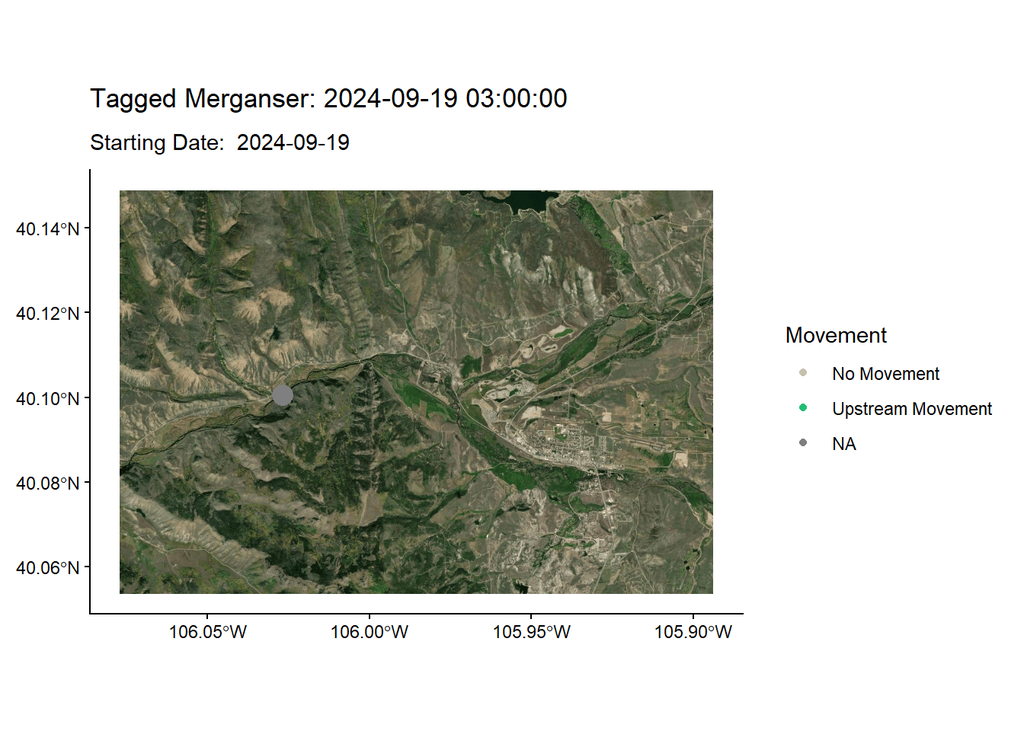

In contrast, below is the encounter history of a 335 mm Brown Trout. Antennas hit follow a logical sequence for fish and there more time between detections at different antenna sites. In contrast to the merganser, the fish lingers on antennas as opposed to only a brief detection at antennas. The fish moves more in the fall, when you’d expect a brown trout to move for the spawn. The fish moves around a lot, but follows a logical sequence of antennas, as shown in the animation below for the selected time frame, when the fish moves upstream through the channel before moving back down and up, hitting all antennas along the way.

| TAG | Datetime | Species | Event | Previous Event | Time Since Previous Detection (For Sorting) | Time Since Previous Detection (User Friendly) |
| --- | --- | --- | --- | --- | --- | --- |
| 230000294213 | 2025-05-05T14:15:00Z | LOC | Release |  |  | First Detection in History |
| 230000294213 | 2025-05-07T14:30:00Z | LOC | Recapture | Release | -173700 | 2.01 days |
| 230000294213 | 2025-05-08T00:11:54Z | LOC | HP4 | Recapture | -34914 | 9.7 hours |
| 230000294213 | 2025-05-08T00:11:58Z | LOC | HP3 | HP4 | -4 | 4 seconds |
| 230000294213 | 2025-05-08T11:15:00Z | LOC | Recapture | HP3 | -39782 | 11.05 hours |
| 230000294213 | 2025-05-12T00:02:17Z | LOC | RB2 | Recapture | -305237 | 3.53 days |
| 230000294213 | 2025-05-12T00:02:20Z | LOC | RB1 | RB2 | -3 | 3 seconds |
| 230000294213 | 2025-10-05T16:37:34Z | LOC | RB1 | RB1 | -12674114 | 146.69 days |
| 230000294213 | 2025-10-05T16:37:57Z | LOC | RB2 | RB1 | -23 | 23 seconds |
| 230000294213 | 2025-10-06T03:42:39Z | LOC | HP3 | RB2 | -39882 | 11.08 hours |

[output cut: 1092 more lines]

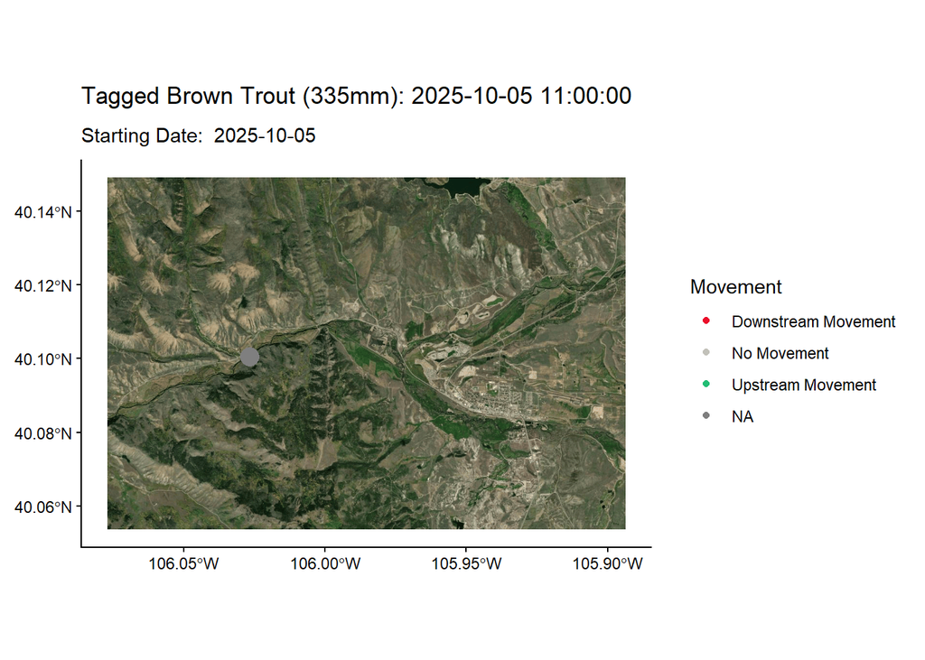